# Analisis Tipe Wine menggunakan K-Means, Hierarchical Clustering dan Factor Analisis

# NAUFAL FADHLUROHMAN (19523216) MAHESA CADI RAJASA (19523122)

## K-Means Clustering

Kami akan melakukan clustering tipe-tipe wine pada dataset Wine yang di dapat dari kaggle Pertama mari kita load beberapa library yang mungkin akan digunakan

```r
library(tidyverse)
library(corrplot)
library(gridExtra)
library(GGally)
library(knitr)
```

Kemudian load dataset wine nya. Kita tidak memerlukan kolom Customer_Segment. Karena k-means adalah unsupervised machine learning algorithm dan hanya bekerja pada unlabeled data.

```r
library(readr)
datawine <- read_csv("Wine.csv")
datawine <- datawine[, -14]
head(datawine)
```

| Alcohol | Malic_Acid | Ash | Ash_Alcanity | Magnesium | Total_Phenols | Flavanoids | Nonflavanoid_Phenols | Proanthocyanins | Color_Intensity | Hue | OD280 | Proline |
| --- | --- | --- | --- | --- | --- | --- | --- | --- | --- | --- | --- | --- |
| 14.23 | 1.71 | 2.43 | 15.6 | 127 | 2.80 | 3.06 | 0.28 | 2.29 | 5.64 | 1.04 | 3.92 | 1065 |
| 13.20 | 1.78 | 2.14 | 11.2 | 100 | 2.65 | 2.76 | 0.26 | 1.28 | 4.38 | 1.05 | 3.40 | 1050 |
| 13.16 | 2.36 | 2.67 | 18.6 | 101 | 2.80 | 3.24 | 0.30 | 2.81 | 5.68 | 1.03 | 3.17 | 1185 |
| 14.37 | 1.95 | 2.50 | 16.8 | 113 | 3.85 | 3.49 | 0.24 | 2.18 | 7.80 | 0.86 | 3.45 | 1480 |
| 13.24 | 2.59 | 2.87 | 21.0 | 118 | 2.80 | 2.69 | 0.39 | 1.82 | 4.32 | 1.04 | 2.93 | 735 |
| 14.20 | 1.76 | 2.45 | 15.2 | 112 | 3.27 | 3.39 | 0.34 | 1.97 | 6.75 | 1.05 | 2.85 | 1450 |

Selanjunjutnya kami melihat summary dan strutuk datasetnya

```r
summary(datawine)
```

```
    Alcohol        Malic_Acid         Ash         Ash_Alcanity     Magnesium      Total_Phenols
 Min.   :11.03   Min.   :0.740   Min.   :1.360   Min.   :10.60   Min.   : 70.00   Min.   :0.980
 1st Qu.:12.36   1st Qu.:1.603   1st Qu.:2.210   1st Qu.:17.20   1st Qu.: 88.00   1st Qu.:1.742
 Median :13.05   Median :1.865   Median :2.360   Median :19.50   Median : 98.00   Median :2.355
 Mean   :13.00   Mean   :2.336   Mean   :2.367   Mean   :19.49   Mean   : 99.74   Mean   :2.295
 3rd Qu.:13.68   3rd Qu.:3.083   3rd Qu.:2.558   3rd Qu.:21.50   3rd Qu.:107.00   3rd Qu.:2.800
 Max.   :14.83   Max.   :5.800   Max.   :3.230   Max.   :30.00   Max.   :162.00   Max.   :3.880
   Flavanoids    Nonflavanoid_Phenols Proanthocyanins Color_Intensity       Hue             OD280
 Min.   :0.340   Min.   :0.1300       Min.   :0.410   Min.   : 1.280   Min.   :0.4800   Min.   :1.270
 1st Qu.:1.205   1st Qu.:0.2700       1st Qu.:1.250   1st Qu.: 3.220   1st Qu.:0.7825   1st Qu.:1.938
 Median :2.135   Median :0.3400       Median :1.555   Median : 4.690   Median :0.9650   Median :2.780
 Mean   :2.029   Mean   :0.3619       Mean   :1.591   Mean   : 5.058   Mean   :0.9574   Mean   :2.612
 3rd Qu.:2.875   3rd Qu.:0.4375       3rd Qu.:1.950   3rd Qu.: 6.200   3rd Qu.:1.1200   3rd Qu.:3.170
 Max.   :5.080   Max.   :0.6600       Max.   :3.580   Max.   :13.000   Max.   :1.7100   Max.   :4.000
    Proline
 Min.   : 278.0
 1st Qu.: 500.5
 Median : 673.5
 Mean   : 746.9
 3rd Qu.: 985.0
 Max.   :1680.0
```

```r
str(datawine)
```

```
tibble [178 x 13] (S3: tbl_df/tbl/data.frame)
 $ Alcohol             : num [1:178] 14.2 13.2 13.2 14.4 13.2 ...
 $ Malic_Acid          : num [1:178] 1.71 1.78 2.36 1.95 2.59 1.76 1.87 2.15 1.64 1.35 ...
 $ Ash                 : num [1:178] 2.43 2.14 2.67 2.5 2.87 2.45 2.45 2.61 2.17 2.27 ...
 $ Ash_Alcanity        : num [1:178] 15.6 11.2 18.6 16.8 21 15.2 14.6 17.6 14 16 ...
 $ Magnesium           : num [1:178] 127 100 101 113 118 112 96 121 97 98 ...
 $ Total_Phenols       : num [1:178] 2.8 2.65 2.8 3.85 2.8 3.27 2.5 2.6 2.8 2.98 ...
 $ Flavanoids          : num [1:178] 3.06 2.76 3.24 3.49 2.69 3.39 2.52 2.51 2.98 3.15 ...
 $ Nonflavanoid_Phenols: num [1:178] 0.28 0.26 0.3 0.24 0.39 0.34 0.3 0.31 0.29 0.22 ...
 $ Proanthocyanins     : num [1:178] 2.29 1.28 2.81 2.18 1.82 1.97 1.98 1.25 1.98 1.85 ...
 $ Color_Intensity     : num [1:178] 5.64 4.38 5.68 7.8 4.32 6.75 5.25 5.05 5.2 7.22 ...
 $ Hue                 : num [1:178] 1.04 1.05 1.03 0.86 1.04 1.05 1.02 1.06 1.08 1.01 ...
 $ OD280               : num [1:178] 3.92 3.4 3.17 3.45 2.93 2.85 3.58 3.58 2.85 3.55 ...
 $ Proline             : num [1:178] 1065 1050 1185 1480 735 ...
```

Baiklah setelah melihat-lihat datasetnya kami mulai memvisualisasikannya ke histogram dan mengekplorasinya lebih dalam lagi.

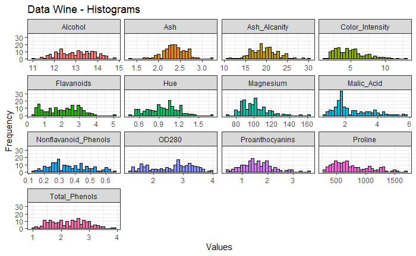

```r
##Data Wine Histogram
datawine %>%
  gather(Attributes, value, 1:13) %>%
  ggplot(aes(x=value, fill=Attributes)) +
  geom_histogram(colour="black", show.legend=FALSE) +
  facet_wrap(~Attributes, scales="free_x") +
  labs(x="Values", y="Frequency",
       title="Data Wine - Histograms") +
  theme_bw()
```

Bagaimana kalau visualisasikan densitynya juga.

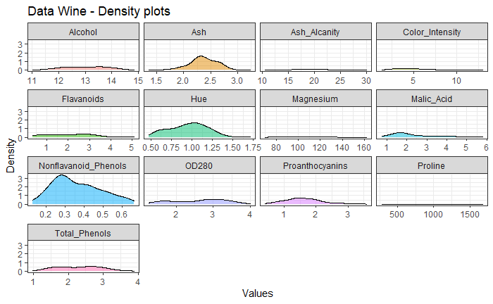

```r
##Data Wine Density
datawine %>%
  gather(Attributes, value, 1:13) %>%
  ggplot(aes(x=value, fill=Attributes)) +
  geom_density(colour="black", alpha=0.5, show.legend=FALSE) +
  facet_wrap(~Attributes, scales="free_x") +
  labs(x="Values", y="Density",
       title="Data Wine - Density plots") +
  theme_bw()
```

Kami bertanya-tanya bagaimana caranya mengetahui hubungan antar atribut yang berbeda, yang akhirnya kami menggunakan fungsi corrplot() untuk membuat atau menampilakn sebuah correlation matrix.

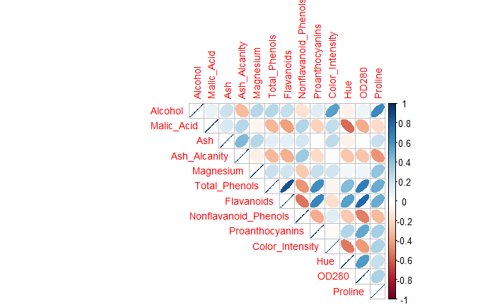

```r
corrplot(cor(datawine), type="upper", method="ellipse", tl.cex=0.9)
```

Kami menemukan hubungan yang kuat antara Total_Phenols dan Flavanoids. Kita bisa memvisualisasikan model hubungan antara atribut tersebut menggunakan ggplot.

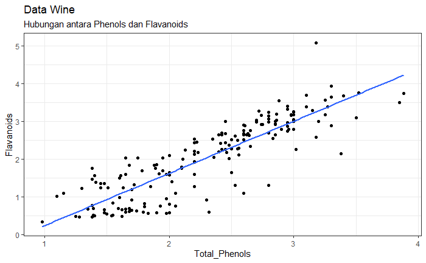

```r
ggplot(datawine, aes(x=Total_Phenols, y=Flavanoids)) +
  geom_point() +
  geom_smooth(method="lm", se=FALSE) +
  labs(title="Data Wine",
       subtitle="Hubungan antara Phenols dan Flavanoids") +
  theme_bw()
```

Nahh, kita bisa lihat hubungan antara Total_Phenols dan Flavanoids yang di fitting sebuah garis linier equation. Kami sudah selesai mengekplorasi data, selanjutnya kami mempersiapkan data untuk dieksekusi menggunakan k-means.

Pertama, kami mencari angka yang optimal untuk clustering menggunakan elbow method “wss” dan nantinya angka yang didapat akan digunakan untuk clustering di k-means.

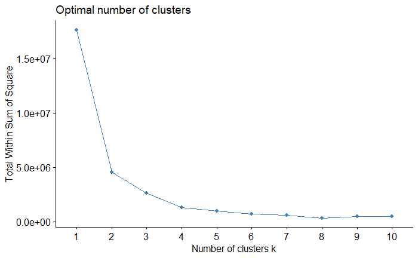

```r
library(factoextra)
set.seed(123)
fviz_nbclust(datawine, kmeans, method = "wss")
```

Bisa kita lihat hasil elbow method yang kami lakukan, didapat optimal number 2. Tetapi untuk lebih memastikan kami melakukan clustering menggunakan dua angka optimal yang berbeda yaitu 2 dan 3.

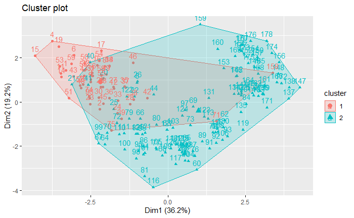

```r
library(cluster)
k2 <- kmeans(datawine, centers = 2, nstart = 25)
k3 <- kmeans(datawine, centers = 3, nstart = 25)
fviz_cluster(k2, data = datawine)
```

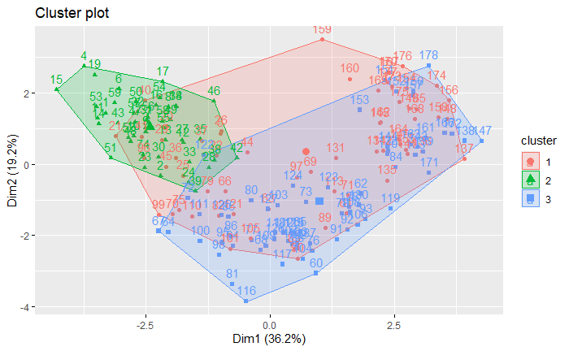

```r
fviz_cluster(k3, data = datawine)
```

```r
k2
```

```
K-means clustering with 2 clusters of sizes 55, 123

Cluster means:
   Alcohol Malic_Acid      Ash Ash_Alcanity Magnesium Total_Phenols Flavanoids Nonflavanoid_Phenols
1 13.66655   1.870727 2.427818     17.45273 106.29091      2.816182   2.896545            0.2929091
2 12.70285   2.544553 2.339106     20.40813  96.81301      2.062114   1.641463            0.3926829
  Proanthocyanins Color_Intensity       Hue    OD280   Proline
1        1.896909        5.520364 1.0666545 3.066727 1151.7273
2        1.454065        4.851382 0.9086179 2.408211  565.8699

Clustering vector:
  [1] 1 1 1 1 2 1 1 1 1 1 1 1 1 1 1 1 1 1 1 2 2 2 1 1 2 2 1 1 1 1 1 1 1 1 1 1 1 1 1 2 2 1 1 2 1 1 1 1 1 1 1 1 1
 [54] 1 1 1 1 1 1 2 2 2 2 2 2 2 2 2 2 2 1 2 2 1 1 2 2 2 2 2 2 2 2 2 2 2 2 2 2 2 2 2 2 2 2 1 2 2 2 2 2 2 2 2 2 2
[107] 2 2 2 2 2 2 2 2 2 2 2 2 2 2 2 2 2 2 2 2 2 2 2 2 2 2 2 2 2 2 2 2 2 2 2 2 2 2 2 2 2 2 2 2 2 2 2 2 2 2 2 1 2
[160] 2 2 2 2 2 2 2 2 2 2 2 2 2 2 2 2 2 2 2

Within cluster sum of squares by cluster:
[1] 1977722 2566028
 (between_SS / total_SS =  74.2 %)

Available components:

[1] "cluster"      "centers"      "totss"        "withinss"     "tot.withinss" "betweenss"    "size"
[8] "iter"         "ifault"
```

```r
k3
```

```
K-means clustering with 3 clusters of sizes 62, 47, 69

Cluster means:
   Alcohol Malic_Acid      Ash Ash_Alcanity Magnesium Total_Phenols Flavanoids Nonflavanoid_Phenols
1 12.92984   2.504032 2.408065     19.89032 103.59677      2.111129   1.584032            0.3883871
2 13.80447   1.883404 2.426170     17.02340 105.51064      2.867234   3.014255            0.2853191
3 12.51667   2.494203 2.288551     20.82319  92.34783      2.070725   1.758406            0.3901449
  Proanthocyanins Color_Intensity       Hue    OD280   Proline
1        1.503387        5.650323 0.8839677 2.365484  728.3387
2        1.910426        5.702553 1.0782979 3.114043 1195.1489
3        1.451884        4.086957 0.9411594 2.490725  458.2319

Clustering vector:
  [1] 2 2 2 2 1 2 2 2 2 2 2 2 2 2 2 2 2 2 2 1 1 1 2 2 1 1 2 2 1 2 2 2 2 2 2 1 1 2 2 1 1 2 2 1 1 2 2 2 2 2 2 2 2
 [54] 2 2 2 2 2 2 3 1 3 1 3 3 1 3 3 1 1 1 3 3 2 1 3 3 3 1 3 3 1 1 3 3 3 3 3 1 1 3 3 3 3 3 1 1 3 1 3 1 3 3 3 1 3
[107] 3 3 3 1 3 3 1 3 3 3 3 3 3 3 1 3 3 3 3 3 3 3 3 3 1 3 3 1 1 1 1 3 3 3 1 1 3 3 1 1 3 1 1 3 3 3 3 1 1 1 3 1 1
[160] 1 3 1 3 1 1 3 1 1 1 1 3 3 1 1 1 1 1 3

Within cluster sum of squares by cluster:
[1]  566572.5 1360950.5  443166.7
 (between_SS / total_SS =  86.5 %)

Available components:

[1] "cluster"      "centers"      "totss"        "withinss"     "tot.withinss" "betweenss"    "size"
[8] "iter"         "ifault"
```

Dari hasil clustering diatas dapat kita lihat pembagian ukuran yang rata adalah cluster=3, jadi kami mendapatkan kesimpulan dataset wine ini bisa atau memungkinkan untuk dibagi menjadi 3 tipe wine.

Berikut dibawah ini adalah cluster plot dari data wine.

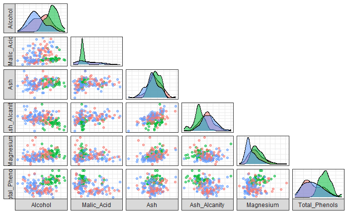

```r
ggpairs(cbind(datawine, Cluster=as.factor(k3$cluster)),
        columns=1:6, aes(colour=Cluster, alpha=0.5),
        lower=list(continuous="points"),
        upper=list(continuous="blank"),
        axisLabels="none", switch="both") +
        theme_bw()
```

## Hierarchical Clustering Complate Linkage

Kemudian kami melakukan hirarchical clustering complate linkage untuk lebih memastikan apakah data wine akan bagus jika dibagi menjadi 3 tipe wine.

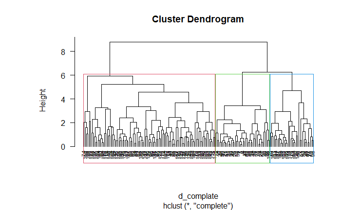

```r
df_complate <- data.frame(States=rownames(datawine), datawine)
par(las=2) # make label text perpendicular to axis
par(mar=c(5,8,4,2)) # increase y-axis margin.

df_complate <- scale(df_complate[, 2:5])
d_complate <- dist(df_complate, method = "euclidean")
clusters_complate <- hclust(d_complate, method = "complete")
plot(clusters_complate, cex = 0.6, hang = -1)
rect.hclust(clusters_complate, k = 3, border = 2:5)
```

Dapat dilihat dari hasil clustering diatas kita mendapati pembagian data yang tidak rata antara cluster 1(merah) dan cluster 2 (hijau) dan cluster 3 (biru).

## Factor Analysis

Selanjunya kami menganalisis faktor dari dataset wine tersebut menggunakan Factor Analysis. Pertama kami cari terlebih dahulu jumlah faktor yang tepat dengan menggunakan scree plot

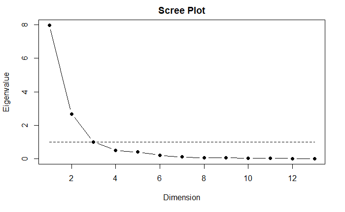

```r
library(psych)
library(psy)
scree.plot(cor(datawine))
```

Dari hasil scree plot diatas kita mendapatkan jumlah faktor = 3, kita akan pakai nilai ini sebagai jumlah faktor.

Selanjutnya kami mencari variance dari dataset wine tersebut

```r
modelFA <- fa(r = datawine, nfactors = 3, rotate = "varimax", fm="minres")
modelFA$loadings
```

```
Loadings:
                     MR1    MR2    MR3
Alcohol                      0.798
Malic_Acid           -0.495         0.228
Ash                          0.312  0.727
Ash_Alcanity         -0.301 -0.306  0.752
Magnesium             0.168  0.396  0.121
Total_Phenols         0.798  0.336
Flavanoids            0.921  0.263
Nonflavanoid_Phenols -0.520 -0.170  0.244
Proanthocyanins       0.592  0.221
Color_Intensity      -0.427  0.712  0.113
Hue                   0.678 -0.176 -0.144
OD280                 0.862
Proline               0.376  0.727

                 MR1   MR2   MR3
SS loadings    3.998 2.319 1.271
Proportion Var 0.308 0.178 0.098
Cumulative Var 0.308 0.486 0.584
```

Pada baris Cumulative var dapat kita lihat besaran variance kumulatif masing-masing faktor adalah MR1 sebesar 30%, MR2 sebesar 49%, dan MR3 sebesar 58%. Dari baris Proportion Var dapat kita lihat besaran variance yang dijelaskan masing-masing faktor, dan jika ditotal kita mendapatkan sekitar 58% total variance. Ini dapat di artikan bahwa model FA yang kita buat di atas merepresentasikan 58% informasi yang dikandung data set yang analisis.

Selanjutnya kita memodelkan data menggunakan jumlah faktor yang sudah kita dapatkan sebelumnya.

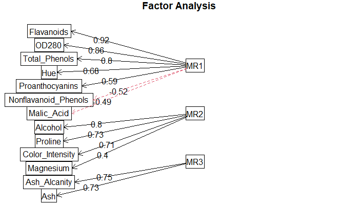

```r
load <- modelFA$loadings[,1:2]
fa.diagram(modelFA, digits = 2)
```

Dari model Factor Analysis di atas, dapat kita lihat Flavanoids, OD280, Total_Phenols, Hue, Proanthocyanins, Nonflavanoid_Phenols, Malic_Acid berasosiasi disebabkan oleh faktor 1 atau MR1, sedangkan Alcohol, Proline, Color_Intensity, Magnesium berasosiasi disebabkan oleh faktor 2 atau MR2, dan Ash_Alcanity, Ash berasosiasi disebabkan oleh faktor 3 atau MR3.